# Climate Change Explorer

##### ClimateChangeExplorer is a data analysis project focusing on global climate trends from 1961 to 2022, with predictive insights up to 2050. Leveraging Jupyter Notebooks, it offers data cleaning, visualization, and predictive modeling for understanding and forecasting climate change dynamics.

```python
import pandas as pd
import numpy as np
import matplotlib as plt
import matplotlib.pyplot as plt
from scipy.stats import linregress
import seaborn as sns
import plotly.express as px
```

## Data exploration

### Visualization of my DataFrame:

- ObjectId: A unique identifier for each row in the table.
- Country: The name of the country.
- ISO2: The 2-letter ISO code of the country.
- ISO3: The 3-letter ISO code of the country.
- Indicator: Describes the type of climate indicator, in this case, 'Temperature change with respect to a baseline climatology, corresponding to the period 1951-1980'.
- Unit: The unit in which the indicator is measured, in this case, degrees Celsius.
- Source: The source of the data.
- CTS_Code: Code related to surface temperature change.
- CTS_Name: Name related to surface temperature change.
- CTS_Full_Descriptor: Complete description of surface temperature change.
- F1961 to F2022: Columns representing temperature changes for each year from 1961 to 2022.

```python
df = pd.read_csv('climate_change_indicators.csv')
```

```python
df.head()
```

|  | ObjectId | Country | ISO2 | ISO3 | Indicator | Unit | Source | CTS_Code | CTS_Name | CTS_Full_Descriptor | ... | F2013 | F2014 | F2015 | F2016 | F2017 | F2018 | F2019 | F2020 | F2021 | F2022 |
| --- | --- | --- | --- | --- | --- | --- | --- | --- | --- | --- | --- | --- | --- | --- | --- | --- | --- | --- | --- | --- | --- |
| 0 | 1 | Afghanistan, Islamic Rep. of | AF | AFG | Temperature change with respect to a baseline ... | Degree Celsius | Food and Agriculture Organization of the Unite... | ECCS | Surface Temperature Change | Environment, Climate Change, Climate Indicator... | ... | 1.28 | 0.46 | 1.09 | 1.55 | 1.54 | 1.54 | 0.91 | 0.50 | 1.33 | 2.01 |
| 1 | 2 | Albania | AL | ALB | Temperature change with respect to a baseline ... | Degree Celsius | Food and Agriculture Organization of the Unite... | ECCS | Surface Temperature Change | Environment, Climate Change, Climate Indicator... | ... | 1.33 | 1.20 | 1.57 | 1.46 | 1.12 | 2.03 | 1.68 | 1.50 | 1.54 | 1.52 |
| 2 | 3 | Algeria | DZ | DZA | Temperature change with respect to a baseline ... | Degree Celsius | Food and Agriculture Organization of the Unite... | ECCS | Surface Temperature Change | Environment, Climate Change, Climate Indicator... | ... | 1.19 | 1.69 | 1.12 | 1.76 | 1.51 | 1.21 | 1.11 | 1.93 | 2.33 | 1.69 |
| 3 | 4 | American Samoa | AS | ASM | Temperature change with respect to a baseline ... | Degree Celsius | Food and Agriculture Organization of the Unite... | ECCS | Surface Temperature Change | Environment, Climate Change, Climate Indicator... | ... | 1.26 | 1.17 | 1.01 | 1.54 | 1.44 | 1.19 | 1.54 | 1.43 | 1.27 | 1.26 |
| 4 | 5 | Andorra, Principality of | AD | AND | Temperature change with respect to a baseline ... | Degree Celsius | Food and Agriculture Organization of the Unite... | ECCS | Surface Temperature Change | Environment, Climate Change, Climate Indicator... | ... | 0.83 | 1.95 | 1.69 | 1.99 | 1.93 | 1.92 | 1.96 | 2.56 | 1.53 | 3.24 |

5 rows × 72 columns

```python
df.info()
```

```
<class 'pandas.core.frame.DataFrame'>
RangeIndex: 225 entries, 0 to 224
Data columns (total 72 columns):
 #   Column               Non-Null Count  Dtype
---  ------               --------------  -----
 0   ObjectId             225 non-null    int64
 1   Country              225 non-null    object
 2   ISO2                 223 non-null    object
 3   ISO3                 225 non-null    object
 4   Indicator            225 non-null    object
 5   Unit                 225 non-null    object
 6   Source               225 non-null    object
 7   CTS_Code             225 non-null    object
 8   CTS_Name             225 non-null    object
 9   CTS_Full_Descriptor  225 non-null    object
```

[output cut: 64 more lines]

```python
df.describe()
```

|  | ObjectId | F1961 | F1962 | F1963 | F1964 | F1965 | F1966 | F1967 | F1968 | F1969 | ... | F2013 | F2014 | F2015 | F2016 | F2017 | F2018 | F2019 | F2020 | F2021 | F2022 |
| --- | --- | --- | --- | --- | --- | --- | --- | --- | --- | --- | --- | --- | --- | --- | --- | --- | --- | --- | --- | --- | --- |
| count | 225.00 | 188.00 | 189.00 | 188.00 | 188.00 | 188.00 | 192.00 | 191.00 | 191.00 | 190.00 | ... | 216.00 | 216.00 | 216.00 | 213.00 | 214.00 | 213.00 | 213.00 | 212.00 | 213.00 | 213.00 |
| mean | 113.00 | 0.16 | -0.01 | -0.01 | -0.07 | -0.25 | 0.11 | -0.11 | -0.20 | 0.16 | ... | 0.93 | 1.11 | 1.27 | 1.44 | 1.28 | 1.30 | 1.44 | 1.55 | 1.34 | 1.38 |
| std | 65.10 | 0.41 | 0.34 | 0.39 | 0.31 | 0.27 | 0.38 | 0.34 | 0.27 | 0.31 | ... | 0.32 | 0.56 | 0.46 | 0.40 | 0.39 | 0.60 | 0.47 | 0.62 | 0.48 | 0.67 |
| min | 1.00 | -0.69 | -0.91 | -1.27 | -0.88 | -1.06 | -1.80 | -1.05 | -1.63 | -0.90 | ... | 0.12 | -0.09 | -0.43 | 0.25 | 0.02 | 0.24 | 0.05 | 0.23 | -0.42 | -1.30 |
| 25% | 57.00 | -0.10 | -0.16 | -0.21 | -0.24 | -0.39 | -0.04 | -0.26 | -0.34 | -0.01 | ... | 0.74 | 0.74 | 1.02 | 1.15 | 1.03 | 0.86 | 1.17 | 1.16 | 1.02 | 0.88 |
| 50% | 113.00 | 0.06 | -0.06 | -0.00 | -0.06 | -0.23 | 0.10 | -0.15 | -0.19 | 0.20 | ... | 0.90 | 0.99 | 1.22 | 1.45 | 1.28 | 1.12 | 1.41 | 1.48 | 1.33 | 1.31 |
| 75% | 169.00 | 0.32 | 0.11 | 0.23 | 0.13 | -0.09 | 0.28 | 0.01 | -0.07 | 0.35 | ... | 1.19 | 1.34 | 1.52 | 1.71 | 1.53 | 1.83 | 1.70 | 1.83 | 1.63 | 1.92 |
| max | 225.00 | 1.89 | 1.00 | 1.20 | 1.10 | 0.86 | 1.15 | 1.13 | 0.48 | 0.94 | ... | 1.64 | 2.70 | 2.61 | 2.46 | 2.49 | 2.77 | 2.69 | 3.69 | 2.68 | 3.24 |

8 rows × 63 columns

## Data cleaning and transformation

- Dropping duplicate values (no duplicate values exist).
- Transformation of year columns (remove 'F' from column names).
- Handling null values (transform null values to the mean, avoid data loss).

```python
df.shape
```

```
(225, 72)
```

```python
column_names= df.columns
new_column_names = {col: col[1:] for col in column_names if col.startswith('F')}
df.rename(columns=new_column_names, inplace=True)
```

```python
df.drop_duplicates()
```

|  | ObjectId | Country | ISO2 | ISO3 | Indicator | Unit | Source | CTS_Code | CTS_Name | CTS_Full_Descriptor | ... | 2013 | 2014 | 2015 | 2016 | 2017 | 2018 | 2019 | 2020 | 2021 | 2022 |
| --- | --- | --- | --- | --- | --- | --- | --- | --- | --- | --- | --- | --- | --- | --- | --- | --- | --- | --- | --- | --- | --- |
| 0 | 1 | Afghanistan, Islamic Rep. of | AF | AFG | Temperature change with respect to a baseline ... | Degree Celsius | Food and Agriculture Organization of the Unite... | ECCS | Surface Temperature Change | Environment, Climate Change, Climate Indicator... | ... | 1.28 | 0.46 | 1.09 | 1.55 | 1.54 | 1.54 | 0.91 | 0.50 | 1.33 | 2.01 |
| 1 | 2 | Albania | AL | ALB | Temperature change with respect to a baseline ... | Degree Celsius | Food and Agriculture Organization of the Unite... | ECCS | Surface Temperature Change | Environment, Climate Change, Climate Indicator... | ... | 1.33 | 1.20 | 1.57 | 1.46 | 1.12 | 2.03 | 1.68 | 1.50 | 1.54 | 1.52 |
| 2 | 3 | Algeria | DZ | DZA | Temperature change with respect to a baseline ... | Degree Celsius | Food and Agriculture Organization of the Unite... | ECCS | Surface Temperature Change | Environment, Climate Change, Climate Indicator... | ... | 1.19 | 1.69 | 1.12 | 1.76 | 1.51 | 1.21 | 1.11 | 1.93 | 2.33 | 1.69 |
| 3 | 4 | American Samoa | AS | ASM | Temperature change with respect to a baseline ... | Degree Celsius | Food and Agriculture Organization of the Unite... | ECCS | Surface Temperature Change | Environment, Climate Change, Climate Indicator... | ... | 1.26 | 1.17 | 1.01 | 1.54 | 1.44 | 1.19 | 1.54 | 1.43 | 1.27 | 1.26 |
| 4 | 5 | Andorra, Principality of | AD | AND | Temperature change with respect to a baseline ... | Degree Celsius | Food and Agriculture Organization of the Unite... | ECCS | Surface Temperature Change | Environment, Climate Change, Climate Indicator... | ... | 0.83 | 1.95 | 1.69 | 1.99 | 1.93 | 1.92 | 1.96 | 2.56 | 1.53 | 3.24 |
| ... | ... | ... | ... | ... | ... | ... | ... | ... | ... | ... | ... | ... | ... | ... | ... | ... | ... | ... | ... | ... | ... |
| 220 | 221 | Western Sahara | EH | ESH | Temperature change with respect to a baseline ... | Degree Celsius | Food and Agriculture Organization of the Unite... | ECCS | Surface Temperature Change | Environment, Climate Change, Climate Indicator... | ... | 1.42 | 1.40 | 1.51 | 1.73 | 2.20 | 0.94 | 1.48 | 2.07 | 1.59 | 1.97 |
| 221 | 222 | World | NaN | WLD | Temperature change with respect to a baseline ... | Degree Celsius | Food and Agriculture Organization of the Unite... | ECCS | Surface Temperature Change | Environment, Climate Change, Climate Indicator... | ... | 1.02 | 1.05 | 1.41 | 1.66 | 1.43 | 1.29 | 1.44 | 1.71 | 1.45 | 1.39 |
| 222 | 223 | Yemen, Rep. of | YE | YEM | Temperature change with respect to a baseline ... | Degree Celsius | Food and Agriculture Organization of the Unite... | ECCS | Surface Temperature Change | Environment, Climate Change, Climate Indicator... | ... | NaN | NaN | NaN | NaN | NaN | NaN | NaN | NaN | NaN | NaN |
| 223 | 224 | Zambia | ZM | ZMB | Temperature change with respect to a baseline ... | Degree Celsius | Food and Agriculture Organization of the Unite... | ECCS | Surface Temperature Change | Environment, Climate Change, Climate Indicator... | ... | 0.79 | 0.92 | 1.45 | 1.40 | 0.10 | 0.65 | 0.85 | 0.89 | 0.82 | 0.69 |
| 224 | 225 | Zimbabwe | ZW | ZWE | Temperature change with respect to a baseline ... | Degree Celsius | Food and Agriculture Organization of the Unite... | ECCS | Surface Temperature Change | Environment, Climate Change, Climate Indicator... | ... | 0.12 | 0.03 | 0.97 | 1.27 | 0.09 | 0.45 | 0.93 | 0.39 | -0.12 | -0.49 |

225 rows × 72 columns

```python
df_notnull = df.dropna()
```

```python
df_notnull.shape
```

```
(156, 72)
```

```python
df.isnull().sum()
```

```
ObjectId      0
Country       0
ISO2          2
ISO3          0
Indicator     0
             ..
2018         12
2019         12
2020         13
2021         12
2022         12
Length: 72, dtype: int64
```

```python
df=df.drop('ISO2', axis=1)
```

```python
columns_float = df.select_dtypes(include='float64').columns
```

```python
for column in columns_float:
    mean_column = df[column].mean()
    df[column] = df[column].fillna(mean_column)
```

```python
df.isnull().sum()
```

```
ObjectId     0
Country      0
ISO3         0
Indicator    0
Unit         0
            ..
2018         0
2019         0
2020         0
2021         0
2022         0
Length: 71, dtype: int64
```

```python
df.shape
```

```
(225, 71)
```

```python
df.head()
```

|  | ObjectId | Country | ISO3 | Indicator | Unit | Source | CTS_Code | CTS_Name | CTS_Full_Descriptor | 1961 | ... | 2013 | 2014 | 2015 | 2016 | 2017 | 2018 | 2019 | 2020 | 2021 | 2022 |
| --- | --- | --- | --- | --- | --- | --- | --- | --- | --- | --- | --- | --- | --- | --- | --- | --- | --- | --- | --- | --- | --- |
| 0 | 1 | Afghanistan, Islamic Rep. of | AFG | Temperature change with respect to a baseline ... | Degree Celsius | Food and Agriculture Organization of the Unite... | ECCS | Surface Temperature Change | Environment, Climate Change, Climate Indicator... | -0.11 | ... | 1.28 | 0.46 | 1.09 | 1.55 | 1.54 | 1.54 | 0.91 | 0.50 | 1.33 | 2.01 |
| 1 | 2 | Albania | ALB | Temperature change with respect to a baseline ... | Degree Celsius | Food and Agriculture Organization of the Unite... | ECCS | Surface Temperature Change | Environment, Climate Change, Climate Indicator... | 0.63 | ... | 1.33 | 1.20 | 1.57 | 1.46 | 1.12 | 2.03 | 1.68 | 1.50 | 1.54 | 1.52 |
| 2 | 3 | Algeria | DZA | Temperature change with respect to a baseline ... | Degree Celsius | Food and Agriculture Organization of the Unite... | ECCS | Surface Temperature Change | Environment, Climate Change, Climate Indicator... | 0.16 | ... | 1.19 | 1.69 | 1.12 | 1.76 | 1.51 | 1.21 | 1.11 | 1.93 | 2.33 | 1.69 |
| 3 | 4 | American Samoa | ASM | Temperature change with respect to a baseline ... | Degree Celsius | Food and Agriculture Organization of the Unite... | ECCS | Surface Temperature Change | Environment, Climate Change, Climate Indicator... | 0.08 | ... | 1.26 | 1.17 | 1.01 | 1.54 | 1.44 | 1.19 | 1.54 | 1.43 | 1.27 | 1.26 |
| 4 | 5 | Andorra, Principality of | AND | Temperature change with respect to a baseline ... | Degree Celsius | Food and Agriculture Organization of the Unite... | ECCS | Surface Temperature Change | Environment, Climate Change, Climate Indicator... | 0.74 | ... | 0.83 | 1.95 | 1.69 | 1.99 | 1.93 | 1.92 | 1.96 | 2.56 | 1.53 | 3.24 |

5 rows × 71 columns

## Descriptive statistics

### Exploratory data analysis

- I work with numerical data and give them appropriate formatting.
- I obtain a single mean for the data in order to understand the trends.
  - General Mean: The overall mean of climate change is approximately 0.5133 degrees Celsius. This indicates that, on average, there has been an increase in global temperature compared to the reference period.
  - General Mode: The overall mode is around 0.1658 degrees Celsius. This suggests that the most commonly observed temperature is around 0.1658 degrees Celsius. While it may not be the most representative temperature of the sample, it shows the central tendency of the most frequent values.
  - General Median: The overall median is 0.4255 degrees Celsius. The median is useful because it is not affected by extreme or outlier values in the data. It indicates that the midpoint of the climate change values is around 0.4255 degrees Celsius.
- The graphs show a clear trend towards increasing temperatures in recent years.

```python
pd.set_option('display.float_format', lambda x: '%.2f' % x)
df.describe()
```

|  | ObjectId | 1961 | 1962 | 1963 | 1964 | 1965 | 1966 | 1967 | 1968 | 1969 | ... | 2013 | 2014 | 2015 | 2016 | 2017 | 2018 | 2019 | 2020 | 2021 | 2022 |
| --- | --- | --- | --- | --- | --- | --- | --- | --- | --- | --- | --- | --- | --- | --- | --- | --- | --- | --- | --- | --- | --- |
| count | 225.00 | 225.00 | 225.00 | 225.00 | 225.00 | 225.00 | 225.00 | 225.00 | 225.00 | 225.00 | ... | 225.00 | 225.00 | 225.00 | 225.00 | 225.00 | 225.00 | 225.00 | 225.00 | 225.00 | 225.00 |
| mean | 113.00 | 0.16 | -0.01 | -0.01 | -0.07 | -0.25 | 0.11 | -0.11 | -0.20 | 0.16 | ... | 0.93 | 1.11 | 1.27 | 1.44 | 1.28 | 1.30 | 1.44 | 1.55 | 1.34 | 1.38 |
| std | 65.10 | 0.37 | 0.31 | 0.35 | 0.28 | 0.25 | 0.35 | 0.31 | 0.25 | 0.28 | ... | 0.32 | 0.55 | 0.45 | 0.39 | 0.38 | 0.58 | 0.45 | 0.60 | 0.47 | 0.65 |
| min | 1.00 | -0.69 | -0.91 | -1.27 | -0.88 | -1.06 | -1.80 | -1.05 | -1.63 | -0.90 | ... | 0.12 | -0.09 | -0.43 | 0.25 | 0.02 | 0.24 | 0.05 | 0.23 | -0.42 | -1.30 |
| 25% | 57.00 | -0.07 | -0.14 | -0.17 | -0.21 | -0.36 | -0.01 | -0.25 | -0.29 | 0.02 | ... | 0.75 | 0.76 | 1.03 | 1.16 | 1.04 | 0.88 | 1.18 | 1.19 | 1.03 | 0.89 |
| 50% | 113.00 | 0.15 | -0.02 | -0.01 | -0.07 | -0.25 | 0.11 | -0.11 | -0.20 | 0.16 | ... | 0.92 | 1.01 | 1.23 | 1.44 | 1.28 | 1.15 | 1.44 | 1.50 | 1.34 | 1.35 |
| 75% | 169.00 | 0.25 | 0.08 | 0.17 | 0.10 | -0.11 | 0.24 | -0.04 | -0.10 | 0.30 | ... | 1.18 | 1.31 | 1.52 | 1.69 | 1.51 | 1.61 | 1.68 | 1.78 | 1.60 | 1.86 |
| max | 225.00 | 1.89 | 1.00 | 1.20 | 1.10 | 0.86 | 1.15 | 1.13 | 0.48 | 0.94 | ... | 1.64 | 2.70 | 2.61 | 2.46 | 2.49 | 2.77 | 2.69 | 3.69 | 2.68 | 3.24 |

8 rows × 63 columns

```python
columns_float = df.select_dtypes(include='float64')
```

```python
columns_float_numeric = columns_float.apply(pd.to_numeric, errors='coerce')
```

```python
mean_general = columns_float_numeric.stack().mean()
mode_general = pd.Series(columns_float_numeric.stack()).mode()[0]
median_general = pd.Series(columns_float_numeric.stack()).median()
```

```python
print(f"Mean general: {mean_general}")
print(f"Mode general: {mode_general}")
print(f"Median general: {median_general}")
```

```
Mean general: 0.5133257312792895
Mode general: 0.1658162162162162
Median general: 0.4255
```

```python
mean_by_year = columns_float.mean(axis=0)
```

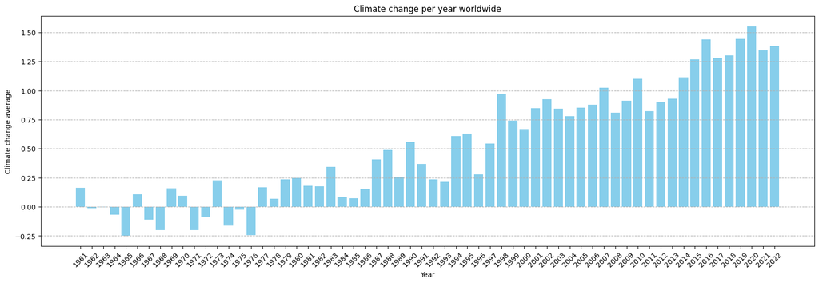

```python
plt.figure(figsize=(20, 6))
plt.bar(mean_by_year.index, mean_by_year.values, color='skyblue')
plt.title('Climate change per year worldwide')
plt.xlabel('Year')
plt.ylabel('Climate change average')
plt.xticks(rotation=45)
plt.grid(axis='y', linestyle='--')
plt.show()
```

```python
labels = columns_float_numeric.columns
```

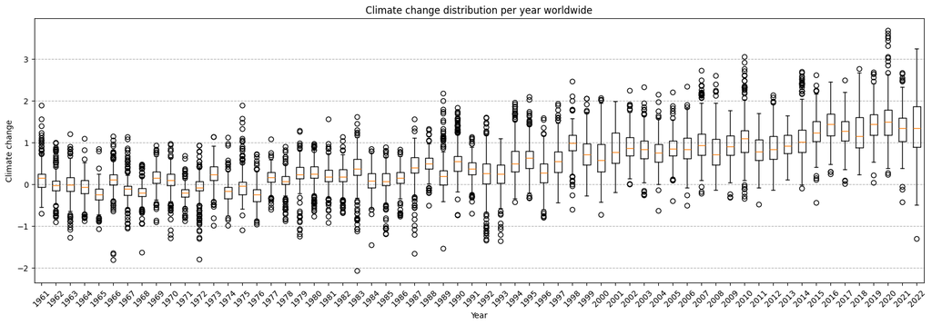

```python
plt.figure(figsize=(20, 6))
plt.boxplot(columns_float_numeric.values, labels=labels)
plt.title('Climate change distribution per year worldwide')
plt.xlabel('Year')
plt.ylabel('Climate change')
plt.xticks(rotation=45)
plt.grid(axis='y', linestyle='--')
plt.show()
```

### Measures of Dispersion

- General Maximum Range: It is useful for understanding the breadth of the observed values.
- Maximum Variance: The maximum variance is approximately 0.4239 square degrees Celsius. Variance measures how spread out the values are relative to the mean. A high variance indicates greater data dispersion around the mean.
- Maximum Standard Deviation: The maximum standard deviation is approximately 0.6511 degrees Celsius. A high standard deviation indicates greater data dispersion relative to the mean.

"These measures of dispersion show that there is considerable variability in the climate change data over time, suggesting that climate changes are not consistent and can be quite significant at times. This highlights the importance of considering variability and not just measures of central tendency when analyzing climate data."

```python
rangere= columns_float.max() - columns_float.min()
print(rangere)
```

```
1961   2.59
1962   1.91
1963   2.47
1964   1.97
1965   1.92
       ...
2018   2.53
2019   2.64
2020   3.46
2021   3.10
2022   4.55
Length: 62, dtype: float64
```

```python
rangere_general = rangere.max()
print(rangere_general)
```

```
4.548
```

```python
columns_float.var().max()
```

```
0.42393784507042254
```

```python
columns_float.std().max()
```

```
0.6511050952576108
```

### Correlation

#### In the correlation plot, it is observed that the values are generally close to 0 or -0 before 1999 and then tend to be closer to 0 and 1 after that year. This may indicate a change in temperature trends over time.

- Hypothesis of Climate Change: The shift in the distribution of temperature values after 1999 could be indicative of ongoing climate change. Values closer to 0 and 1 might reflect an increase in average temperatures and greater variability in recorded temperatures.

```python
columns_year = df.filter(regex=r'^\d{4}$', axis=1)
```

```python
df_new= df[columns_year.columns].copy()
```

```python
df_new.head()
```

|  | 1961 | 1962 | 1963 | 1964 | 1965 | 1966 | 1967 | 1968 | 1969 | 1970 | ... | 2013 | 2014 | 2015 | 2016 | 2017 | 2018 | 2019 | 2020 | 2021 | 2022 |
| --- | --- | --- | --- | --- | --- | --- | --- | --- | --- | --- | --- | --- | --- | --- | --- | --- | --- | --- | --- | --- | --- |
| 0 | -0.11 | -0.16 | 0.85 | -0.76 | -0.24 | 0.23 | -0.37 | -0.42 | -0.54 | 0.81 | ... | 1.28 | 0.46 | 1.09 | 1.55 | 1.54 | 1.54 | 0.91 | 0.50 | 1.33 | 2.01 |
| 1 | 0.63 | 0.33 | 0.07 | -0.17 | -0.39 | 0.56 | -0.07 | 0.08 | -0.01 | -0.11 | ... | 1.33 | 1.20 | 1.57 | 1.46 | 1.12 | 2.03 | 1.68 | 1.50 | 1.54 | 1.52 |
| 2 | 0.16 | 0.11 | 0.08 | 0.25 | -0.10 | 0.43 | -0.03 | -0.07 | 0.29 | 0.12 | ... | 1.19 | 1.69 | 1.12 | 1.76 | 1.51 | 1.21 | 1.11 | 1.93 | 2.33 | 1.69 |
| 3 | 0.08 | -0.04 | 0.17 | -0.14 | -0.56 | 0.18 | -0.37 | -0.19 | 0.13 | -0.05 | ... | 1.26 | 1.17 | 1.01 | 1.54 | 1.44 | 1.19 | 1.54 | 1.43 | 1.27 | 1.26 |
| 4 | 0.74 | 0.11 | -0.75 | 0.31 | -0.49 | 0.41 | 0.64 | 0.02 | -0.14 | 0.12 | ... | 0.83 | 1.95 | 1.69 | 1.99 | 1.93 | 1.92 | 1.96 | 2.56 | 1.53 | 3.24 |

5 rows × 62 columns

```python
df_new.quantile(0.25).mean()
```

```
0.30609677419354836
```

```python
df_new.quantile(0.5).mean()
```

```
0.49509436541016033
```

```python
df_new.quantile(0.75).mean()
```

```
0.7064193548387095
```

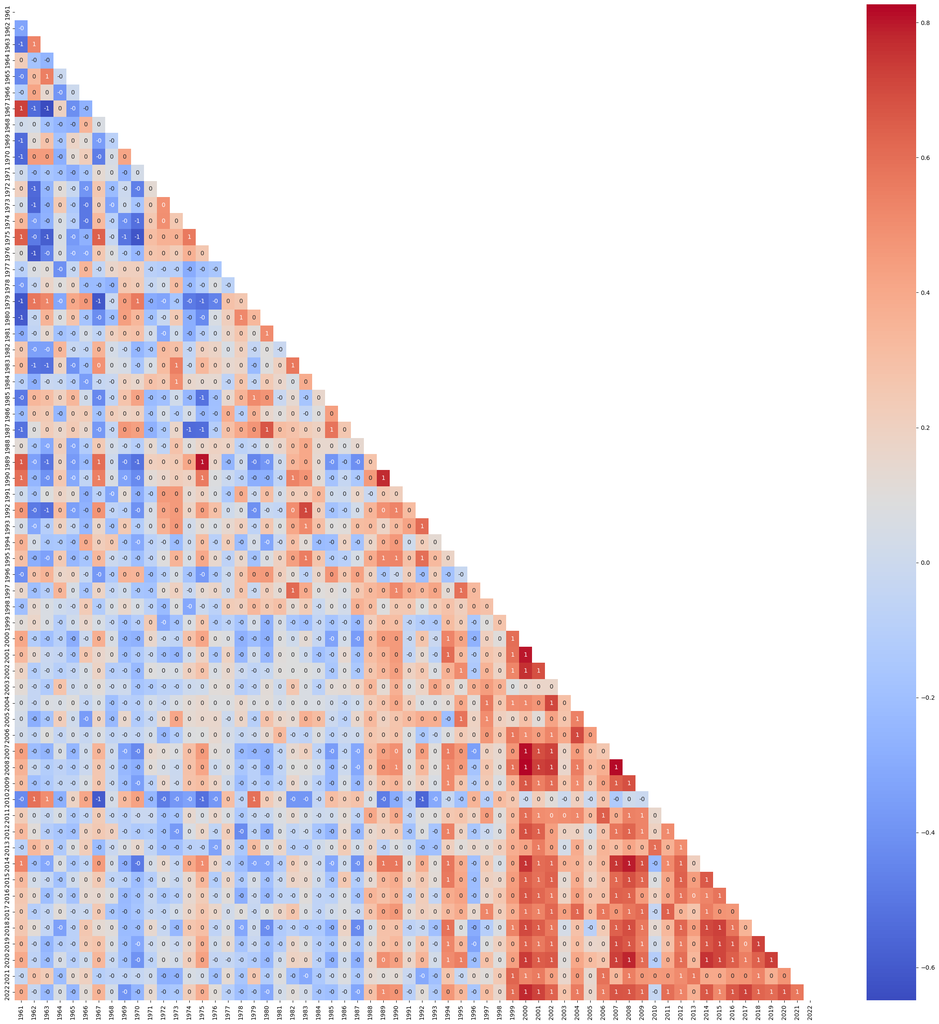

```python
correlation_matrix = df_new.corr()
mask = np.triu(np.ones_like(correlation_matrix, dtype=bool))
plt.figure(figsize=(30, 30))
sns.heatmap(correlation_matrix, mask=mask, cmap='coolwarm', fmt=".0f", annot=True)
plt.show()
```

## Interactive visualization

- I create graphs with the Plotly library that show quite interesting data. We can see in the box plot how the values tend to approach the mean, reducing the outliers. And in the following scatter plots, we observe a notable trend towards increasing temperatures worldwide.

[interactive chart not shown]

```python
fig = px.box(columns_float_numeric, labels={"value": "Value"})
fig.update_layout(title='Box plot showing the trend of temperature change each year')
fig.show()
```

[interactive chart not shown]

```python
fig = px.scatter(df, x="1961", y="Country", color ="1961")
fig.update_layout(title='Scatter plot showing the variance of temperature in 1961 in each country')
fig.show()
```

[interactive chart not shown]

```python
fig = px.scatter(df, x="1996", y="Country", color ="1996")
fig.update_layout(title='Scatter plot showing the variance of temperature in 1996 in each country')
fig.show()
```

[interactive chart not shown]

```python
fig = px.scatter(df, x="2000", y="Country", color ="2000")
fig.update_layout(title='Scatter plot showing the variance of temperature in 2000 in each country')
fig.show()
```

[interactive chart not shown]

```python
fig = px.scatter(df, x="2022", y="Country", color ="2022")
fig.update_layout(title='Scatter plot showing the variance of temperature in 2022 in each country')
fig.show()
```

## Estimation lines

- First, I generate a new DataFrame with a column for years and another with the mean temperature variation worldwide for each year.
- I create a scatter plot to visualize the means.
- To create the regression line, I need to work with numerical data, so I convert the data in the 'year' column into integers
- Then, I calculate the slope and intercept of the regression line that best fits your data, allowing you to make linear predictions based on the independent variable (year) for the dependent variable (means_world).
- I create several approximation models, finally, I combine models to determine the slope.

```python
year = df_new.columns
```

```python
means = df_new.mean()
```

```python
df_means = pd.DataFrame({'year': year, 'mean_world': means})

df_means.reset_index(drop=True, inplace=True)
df_means.index = df_means.index + 1
```

```python
df_means.head()
```

|  | year | mean_world |
| --- | --- | --- |
| 1 | 1961 | 0.16 |
| 2 | 1962 | -0.01 |
| 3 | 1963 | -0.01 |
| 4 | 1964 | -0.07 |
| 5 | 1965 | -0.25 |

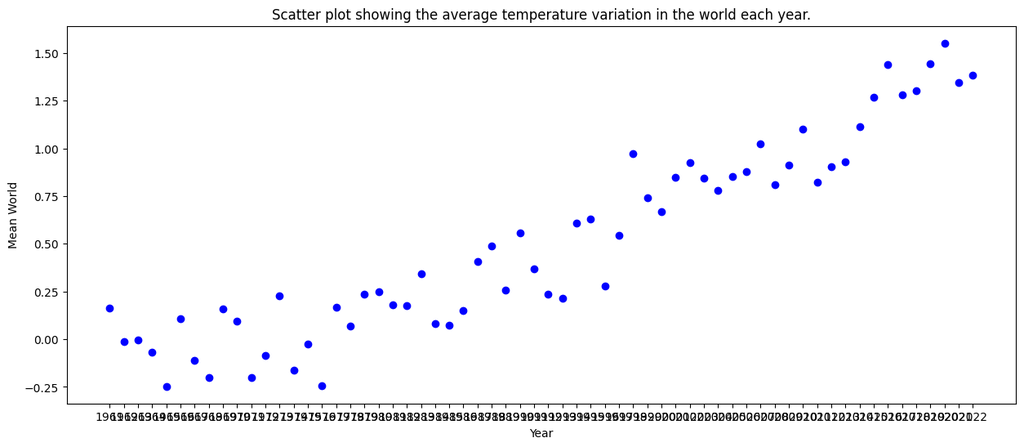

```python
fig, ax = plt.subplots(figsize=(15, 6))
plt.scatter(df_means['year'], df_means['mean_world'], color='blue', label='Data')
plt.title('Scatter plot showing the average temperature variation in the world each year.')
plt.xlabel('Year')
plt.ylabel('Mean World')
plt.show()
```

```python
df_means['year'] = pd.to_numeric(df_means['year'])
```

```python
print(df_means.dtypes)
```

```
year            int64
mean_world    float64
dtype: object
```

```python
slope, intercept, _, _, _  = linregress(df_means['year'], df_means['mean_world'])
```

```python
x_range = np.arange(1961, 2051)
y_values = slope * x_range + intercept
```

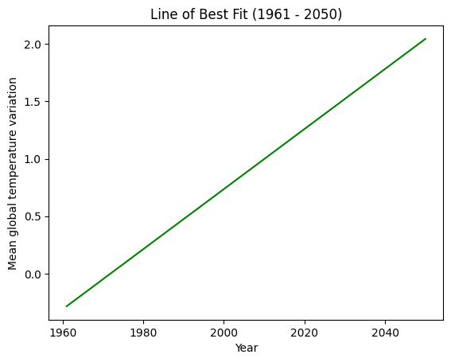

```python
plt.plot(x_range, y_values, color='green', label='Line of Best Fit (1961 - 2050)')
plt.title('Line of Best Fit (1961 - 2050)')
plt.xlabel('Year')
plt.ylabel('Mean global temperature variation')
plt.show()
```

```python
x_range_recent = np.arange(2010, 2051)
y_values_recent = slope * x_range_recent + intercept
```

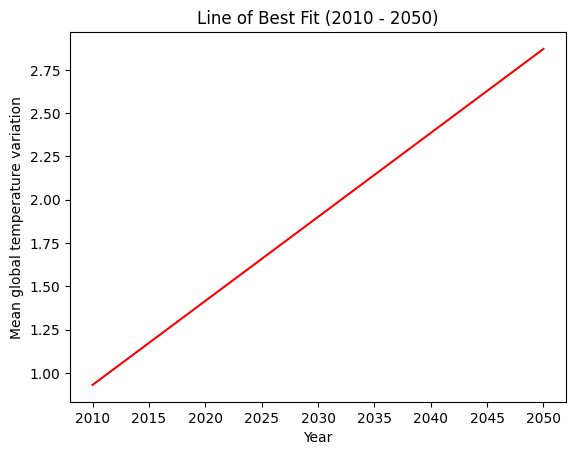

```python
recent_years_data = df_means[df_means['year'] >= 2010]
slope_recent, intercept_recent, _, _, _ = linregress(recent_years_data['year'], recent_years_data['mean_world'])
x_range_recent = np.arange(2010, 2051)
y_values_recent = slope_recent * x_range_recent + intercept_recent
plt.plot(x_range_recent, y_values_recent, color='red', label='Line of Best Fit (2010 - Recent)')
plt.title('Line of Best Fit (2010 - 2050)')
plt.xlabel('Year')
plt.ylabel('Mean global temperature variation')
plt.show()
```

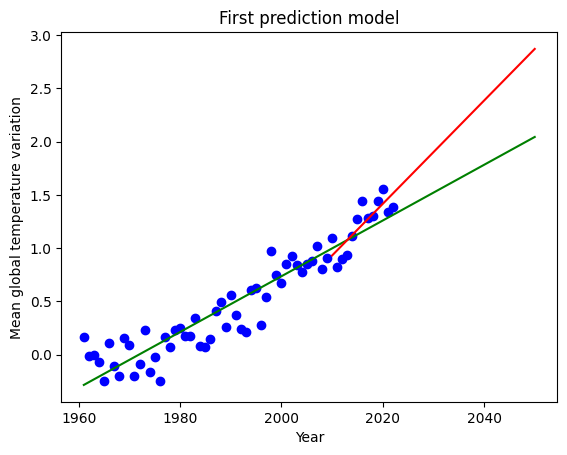

```python
plt.scatter(df_means['year'], df_means['mean_world'], color='blue', label='Data')
plt.plot(x_range, y_values, color='green', label='Line of Best Fit (1961 - 2050)')
plt.plot(x_range_recent, y_values_recent, color='red', label='Line of Best Fit (2010 - Recent)')
plt.xlabel('Year')
plt.ylabel('Mean global temperature variation')
plt.title('First prediction model')
plt.show()
```

```python
regression_data1 = pd.DataFrame({'Year': x_range_recent, 'Prediction_2050': y_values_recent})
```

```python
regression_data1.head()
```

|  | Year | Prediction_2050 |
| --- | --- | --- |
| 0 | 2010 | 0.93 |
| 1 | 2011 | 0.98 |
| 2 | 2012 | 1.03 |
| 3 | 2013 | 1.08 |
| 4 | 2014 | 1.12 |

```python
regression_data2 = pd.DataFrame({'Year': x_range, 'Prediction_2050': y_values})
```

```python
regression_data2
```

|  | Year | Prediction_2050 |
| --- | --- | --- |
| 0 | 1961 | -0.28 |
| 1 | 1962 | -0.26 |
| 2 | 1963 | -0.23 |
| 3 | 1964 | -0.21 |
| 4 | 1965 | -0.18 |
| ... | ... | ... |
| 85 | 2046 | 1.94 |
| 86 | 2047 | 1.97 |
| 87 | 2048 | 1.99 |
| 88 | 2049 | 2.02 |
| 89 | 2050 | 2.04 |

90 rows × 2 columns

# SQL

```python
from sqlalchemy import create_engine, text
from pandasql import sqldf
```

```python
pysqldf = lambda q: sqldf(q, globals())
```

```python
df_means.columns
```

```
Index(['year', 'mean_world'], dtype='object')
```

```python
regression_data2.columns
```

```
Index(['Year', 'Prediction_2050'], dtype='object')
```

```python
q = """SELECT df_means.*, regression_data2.Prediction_2050
FROM df_means
JOIN regression_data2 ON df_means.year = regression_data2.year
"""
pysqldf(q)
```

|  | year | mean_world | Prediction_2050 |
| --- | --- | --- | --- |
| 0 | 1961 | 0.16 | -0.28 |
| 1 | 1962 | -0.01 | -0.26 |
| 2 | 1963 | -0.01 | -0.23 |
| 3 | 1964 | -0.07 | -0.21 |
| 4 | 1965 | -0.25 | -0.18 |
| ... | ... | ... | ... |
| 57 | 2018 | 1.30 | 1.21 |
| 58 | 2019 | 1.44 | 1.23 |
| 59 | 2020 | 1.55 | 1.26 |
| 60 | 2021 | 1.34 | 1.29 |
| 61 | 2022 | 1.38 | 1.31 |

62 rows × 3 columns

```python
df_means_predictions = pysqldf(q)
```

```python
df_means_predictions.to_csv('df_means_predictions.csv', index=False)
```

```python
print(df_means_predictions)
```

```
    year  mean_world  Prediction_2050
0   1961        0.16            -0.28
1   1962       -0.01            -0.26
2   1963       -0.01            -0.23
3   1964       -0.07            -0.21
4   1965       -0.25            -0.18
..   ...         ...              ...
57  2018        1.30             1.21
58  2019        1.44             1.23
59  2020        1.55             1.26
60  2021        1.34             1.29
61  2022        1.38             1.31

[62 rows x 3 columns]
```

```python
df_means_predictions.dtypes
```

```
year                 int64
mean_world         float64
Prediction_2050    float64
dtype: object
```

# Prediction model

Library selection

```python
from sklearn.model_selection import train_test_split
from sklearn.linear_model import LinearRegression
from sklearn.metrics import mean_squared_error
from sklearn.ensemble import RandomForestRegressor
from sklearn.metrics import mean_squared_error
from sklearn.model_selection import cross_val_score
from sklearn.metrics import r2_score
```

Selection of Features

```python
df_means_predictions.columns
```

```
Index(['year', 'mean_world', 'Prediction_2050'], dtype='object')
```

I select the columns with which I want to create my predictive model.

```python
selected_features = ['year', 'mean_world']
```

```python
X = df_means_predictions[selected_features]
y = df_means_predictions['Prediction_2050']
```

Division of data into training and test sets

```python
X_train, X_test, y_train, y_test = train_test_split(X, y, test_size=0.2, random_state=42)
```

```python
print(X_train, X_test, y_train, y_test)
```

```
    year  mean_world
13  1974      -0.163
33  1994       0.610
34  1995       0.629
3   1964      -0.070
17  1978       0.070
54  2015       1.270
8   1969       0.158
6   1967      -0.111
31  1992       0.236
4   1965      -0.247
45  2006       0.877
19  1980       0.247
52  2013       0.931
36  1997       0.544
```

[output cut: 110 more lines]

Model training

```python
model = LinearRegression()
```

```python
model.fit(X_train, y_train)
```

```
LinearRegression()
```

Predictions of model

```python
predictions = model.predict(X_test)
```

```python
predictions
```

```
array([ 1.02364222,  1.18066268, -0.2848616 ,  1.20683276, -0.15401122,
        0.97130207,  0.13385962,  0.02917931,  0.36939031,  1.25917291,
        0.50024069, -0.04933092,  0.94513199])
```

Model evaluation

R-squared = If it is equal to 1, it indicates that the model explains all the variability of the dependent variable.

```python
r_squared = r2_score(y_test, predictions)
print(f'R-squared: {r_squared}')
```

```
R-squared: 1.0
```

Scatter plot

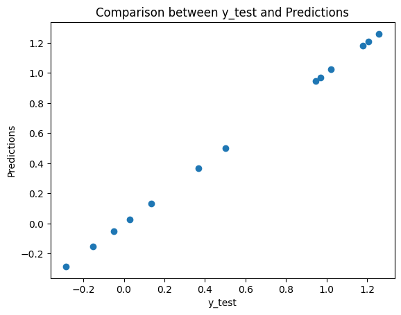

```python
plt.scatter(y_test, predictions)
plt.xlabel('y_test')
plt.ylabel('Predictions')
plt.title('Comparison between y_test and Predictions')
plt.show()
```

```python
pd.set_option('display.float_format', lambda x: '%.3f' % x)


result_table = pd.DataFrame({
    'Country': df.loc[X_test.index, 'Country'],
    'Prediction': predictions,
    'Actual annual temperature': y_test,
})


result_table['Difference'] = result_table['Actual annual temperature'] - result_table['Prediction']

result_table = result_table.sort_values(by='Country', ascending=False)
```

```python
result_table
```

|  | Country | Prediction | Actual annual temperature | Difference |
| --- | --- | --- | --- | --- |
| 59 | El Salvador | 1.259 | 1.259 | 0.000 |
| 57 | Ecuador | 1.207 | 1.207 | 0.000 |
| 56 | Dominican Rep. | 1.181 | 1.181 | 0.000 |
| 50 | Cuba | 1.024 | 1.024 | 0.000 |
| 48 | Costa Rica | 0.971 | 0.971 | 0.000 |
| 47 | Cook Islands | 0.945 | 0.945 | 0.000 |
| 30 | Burkina Faso | 0.500 | 0.500 | 0.000 |
| 25 | Botswana | 0.369 | 0.369 | 0.000 |
| 16 | Bangladesh | 0.134 | 0.134 | 0.000 |
| 12 | Austria | 0.029 | 0.029 | 0.000 |
| 9 | Armenia, Rep. of | -0.049 | -0.049 | 0.000 |
| 5 | Angola | -0.154 | -0.154 | 0.000 |
| 0 | Afghanistan, Islamic Rep. of | -0.285 | -0.285 | 0.000 |

Model analysis

```python
coefficients = model.coef_


coefficients_df = pd.DataFrame({'Variable': X_train.columns, 'Coefficient': coefficients})


coefficients_df = coefficients_df.sort_values(by='Coefficient', ascending=False)


print(coefficients_df)
```

```
     Variable  Coefficient
0        year        0.026
1  mean_world        0.000
```

Cross_validation

```python
cv_scores = cross_val_score(model, X_train, y_train, cv=5, scoring='neg_mean_squared_error')
cv_rmse_scores = np.sqrt(-cv_scores)
```

```python
mse = mean_squared_error(y_test, predictions)
rmse = np.sqrt(mse)

print(f'Test RMSE: {rmse}')
print(f'Test MSE: {mse}')
```

```
Test RMSE: 3.4133368943064214e-15
Test MSE: 1.1650868754033406e-29
```

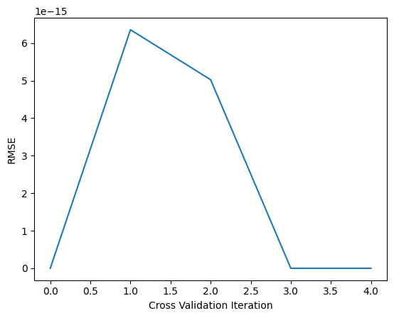

```python
plt.plot(cv_rmse_scores)
plt.xlabel('Cross Validation Iteration')
plt.ylabel('RMSE')
plt.show()
```